# Chamberlin CO2 Emission Analysis

Introducting packages, including gasanalyzR, my own personal set of functions that I’m storing for this type of analysis. I can provide more detail in how this works if necessary.

```r
library(tidyverse)
library(broom)
library(gasanalyzR)
library(colorspace)
```

The data - including some preliminatry wrangling including dropping NAs, selecting only columns that we’ll use. Daily highs temperatures are from PRISM.

```r
CO2_measurements = read.csv("../data/csv/CO2.csv")
  CO2_measurements$peak.heights..um.m. = as.numeric(as.character(CO2_measurements$peak.heights..um.m.))
co2_standards_mV = read.csv("../data/csv/CO2_standards.csv") %>% select(date, std.ppm, co2mV) %>% drop_na()
co2_standards_mmol = read.csv("../data/csv/CO2_standards.csv") %>% select(date, std.ppm, co2mmol.mol) %>% drop_na()
buckets = read.csv("../data/csv/buckets.csv")
dailyhighs = read.csv("../data/csv/dailyhighs.csv")
```

Create standard equations using standard.curve() from gasanalyzR

```r
standard_equations_mV = standard.curve(co2_standards_mV, peak_field = "co2mV", std_field = "std.ppm")
standard_equations_mmol = standard.curve(co2_standards_mmol, peak_field = "co2mmol.mol", std_field = "std.ppm")
```

Wrangling daily high data

```r
high = dailyhighs %>% pivot_longer(cols = starts_with("high")) %>%
  mutate(date = str_remove(name, "high") %>% lubridate::ymd(),
         kelvin = (value + 273.15),
         Plot_ID = tolower(Plot_ID),
         Treatment = tolower(Treatment)) %>%
  select(date, Plot_ID, Treatment, kelvin) %>%
  rename(date.collection = date, site.id = Plot_ID, treatment.type = Treatment)
```

Some of our LICOR measurements are takin in mV, some in micromoles/mol. It shouldn’t matter which, but we have to separate them, and calculate their ppm of CO2 independently before merging them back together. We then add in data about bucket size and temperature

```r
mV = filter(CO2_measurements, date.analysis %in% co2_standards_mV$date)
mmol = filter(CO2_measurements, date.analysis %in% co2_standards_mmol$date)


mV_s = merge(mV, standard_equations_mV, by.x = "date.analysis", by.y = "date")
mmol_s = merge(mmol, standard_equations_mmol, by.x = "date.analysis", by.y = "date")

mV_s$concentration = (mV_s$slope * mV_s$peak.heights..mV.) + mV_s$intercept
mmol_s$concentration = (mmol_s$slope * mmol_s$peak.heights..um.m.) + mmol_s$intercept

all_concentrations = bind_rows(mV_s, mmol_s)

all_concentrations = merge(all_concentrations, buckets, by = "bucket")
all_concentrations$date.collection = lubridate::mdy(all_concentrations$date.collection)
all_concentrations$pressure..atm. = 1

all_concentrations = merge(all_concentrations, high, by = c("date.collection", "site.id", "treatment.type"))
```

Converting ppm CO2 back to grams CO2 using the ideal gas law

```r
#calculate moles and grams of CO2
all_concentrations = all_concentrations %>% mutate(moles = ((pressure..atm. * volume)/(0.082057 * kelvin)) * concentration/1000000,
                                                   grams_co2 = moles * 44.01)
```

Using our timepoints, our grams CO@ measurements, and the bucket size, we can calculate the emission of CO2, in units of gCO2 * m^-2 * hr^-1

```r
#lay out data per bucket and summarize change
c_data = all_concentrations %>%
  select(date.collection, treatment.type, site.id, bucket, Time, grams_co2, QC.Y.N.) %>%
  filter(QC.Y.N. != "Y") %>%
  mutate(timepoint = round(Time/60, 0))

t0 = filter(c_data, timepoint == 0)
t1 = filter(c_data, timepoint == 1)
t2 = filter(c_data, timepoint == 2)

h = merge(t0, t1, by = c("date.collection", "treatment.type", "site.id", "bucket"), all = T)
h = merge(h, t2, by = c("date.collection", "treatment.type", "site.id", "bucket"), all = T)

c_grams_time = h %>%
  select(date.collection, treatment.type, site.id, bucket, Time.x, grams_co2.x, Time.y, grams_co2.y, Time, grams_co2) %>%
  filter(site.id != "alt") %>%
  drop_na() %>%
  rename(T0 = Time.x, T1 = Time.y, T2 = Time, T0co2 = grams_co2.x, T1co2 = grams_co2.y, T2co2 = grams_co2) %>%
  mutate(change1 = ((T1co2 - T0co2)/((T1 - T0)/60))/0.06334707,
         change2 = ((T2co2 - T1co2)/((T2 - T1)/60))/0.06334707,
         change_mean = ((T2co2 - T0co2)/((T2 - T0)/60))/0.06334707,
         date.collection = lubridate::ymd(date.collection),
         changedif = change1 - change2) %>%
  pivot_longer(cols = starts_with("change"))

means = c_grams_time %>% filter(name == "change_mean")
single = c_grams_time %>% filter(name != "change_mean") %>% filter(name != "changedif")
difs = c_grams_time%>% filter(name == "changedif")
```

A quick visualization of the distribution of our mean 2-hr emission measurements

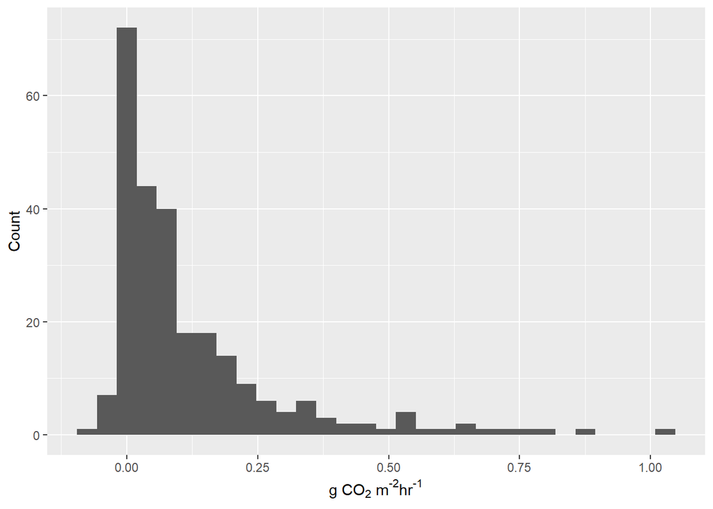

```r
ggplot(means, aes(x = value)) +
  geom_histogram()+
  xlab(expression("g CO"[2]*" m"^"-2" * "hr"^"-1")) +
  ylab("Count")
```

Distribution of individual single-hour measurements

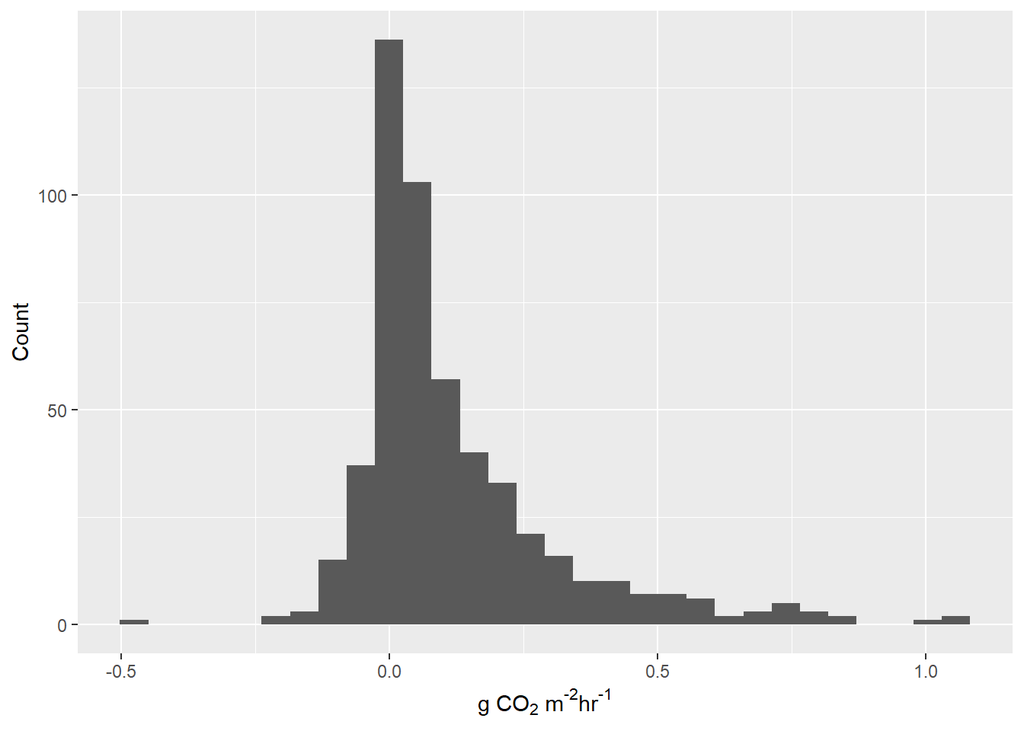

```r
ggplot(single, aes(x = value)) +
  geom_histogram() +
  xlab(expression("g CO"[2]*" m"^"-2" * "hr"^"-1")) +
  ylab("Count")
```

Plotting the distribution of the difference between the first hour and second hour. Values closer to zero indicate a constant rate of emission, values further from zero indicate a change in rate during the incubation.

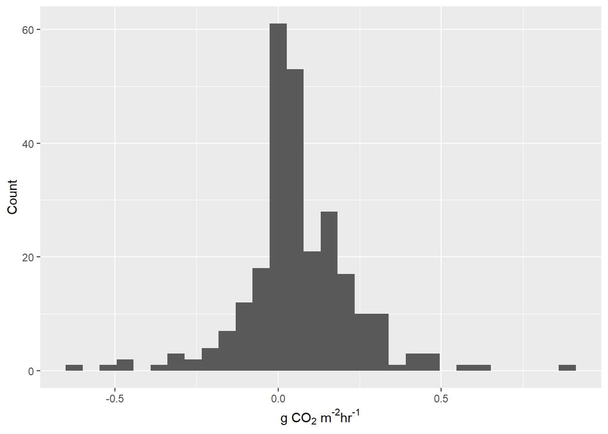

```r
ggplot(difs, aes(x = value)) +
  geom_histogram() +
  xlab(expression("g CO"[2]*" m"^"-2" * "hr"^"-1")) +
  ylab("Count")
```

All of our calculated 2-hr mean emissions data across the last year, separated by site, with treatments and control plots color-coded

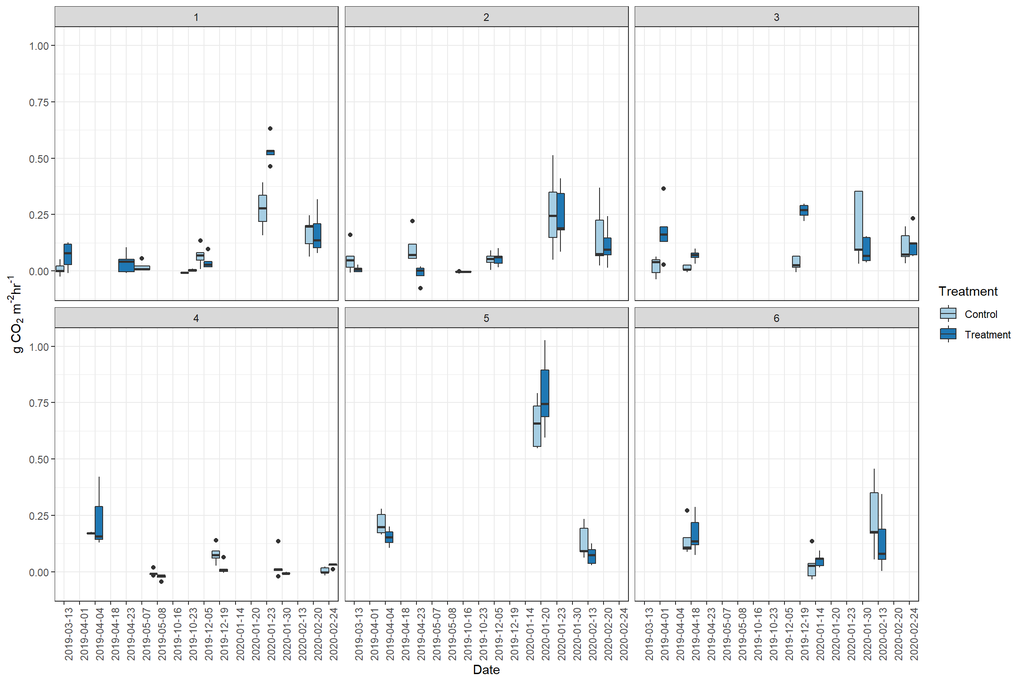

```r
ggplot(means, aes(x = as.factor(date.collection), y = value, fill = treatment.type)) +
  geom_boxplot(position = "dodge", width = 1) +
  facet_wrap(.~site.id) +
  theme_bw() +
  theme(axis.text.x = element_text(angle = 90, hjust = 1)) +
  ylab(expression("g CO"[2]*" m"^"-2" * "hr"^"-1")) +
  xlab("Date") +
  scale_fill_brewer(name = "Treatment", palette = "Paired", labels = c("Control", "Treatment"))
```